# Movie Recommendations

Ming Ming Zhang

## Abstract

We implement the collaborative filtering with regularization algorithm in R, which uses MSE as the loss function and conjugate gradient as the optimization function. Then we apply it to a [dataset of movie ratings](https://grouplens.org/datasets/movielens):

F. Maxwell Harper and Joseph A. Konstan. 2015. The MovieLens Datasets: History and Context. ACM Transactions on Interactive Intelligent Systems (TiiS) 5, 4: 19:1–19:19. https://doi.org/10.1145/2827872.

This dataset was generated by 283228 users between January 09, 1995 and September 26, 2018. It contains 27753444 ratings and 1108997 tag applications across 58098 movies.

We only consider a subset of the dataset, which consists of 1000 users who had rated at least 30 movies over 11288 movies. There are 800 users used in training for the feature matrix $X$ and the user preference matrix, and then by using $X$ along with the metric evaluation MAE, the rest of 200 users is used in cross-validation for determining the regularized parameter. The algorithm of selecting regularized parameter is implemented in R. The number of columns of $X$ such that each one is a feature of movie, is determined by the genres among of the selected 11288 movies.

After learning from the collaborative filtering algorithm with selected regularized parameter, one is tested on the author’s ratings and make personal movie recommendations.

## Rating dataset

```r
ratings = read.csv("~/Downloads/Data/ml-latest/ratings.csv")
length(unique(ratings$movieId))
```

```
[1] 53889
```

```r
length(unique(ratings$userId))
```

```
[1] 283228
```

```r
ratings[ratings$userId==1,]
```

|  | userId | movieId | rating | timestamp |
| --- | --- | --- | --- | --- |
| 1 | 1 | 307 | 3.5 | 1256677221 |
| 2 | 1 | 481 | 3.5 | 1256677456 |
| 3 | 1 | 1091 | 1.5 | 1256677471 |
| 4 | 1 | 1257 | 4.5 | 1256677460 |
| 5 | 1 | 1449 | 4.5 | 1256677264 |
| 6 | 1 | 1590 | 2.5 | 1256677236 |
| 7 | 1 | 1591 | 1.5 | 1256677475 |
| 8 | 1 | 2134 | 4.5 | 1256677464 |
| 9 | 1 | 2478 | 4.0 | 1256677239 |
| 10 | 1 | 2840 | 3.0 | 1256677500 |

[output cut: 6 more lines]

## Training set

```r
# Fix users; each had rated at least N.
usersList = table(ratings$userId)
N = 30
usersList = as.numeric(names(usersList[usersList>N]))
length(usersList)
```

```
[1] 141189
```

```r
head(sort(usersListSample))
```

```
[1]  136  179  351 1068 1812 1964
```

```r
length(usersListSample)
```

```
[1] 800
```

```r
rUsersN = ratings[ratings$userId %in% usersListSample,]
head(rUsersN)
```

|  | userId | movieId | rating | timestamp |
| --- | --- | --- | --- | --- |
| 13388 | 136 | 260 | 4.0 | 1494852354 |
| 13389 | 136 | 356 | 5.0 | 1494850834 |
| 13390 | 136 | 1240 | 4.5 | 1494852401 |
| 13391 | 136 | 1265 | 5.0 | 1494850839 |
| 13392 | 136 | 1580 | 4.5 | 1494851076 |
| 13393 | 136 | 1682 | 4.5 | 1494850856 |

```r
length(unique(rUsersN$movieId))
```

```
[1] 11288
```

```r
length(unique(rUsersN$userId))
```

```
[1] 800
```

```r
tail(movieIdList)
```

```
[1] 192769 192771 193001 193003 193005 193007
```

```r
length(movieIdList)
```

```
[1] 11288
```

```r
m = length(movieIdList)
n = length(unique(rUsersN$userId))
# Return the following matrices, where Y is the ratings m \times n matrix, and R is the corresponding matrix such that R[i,j]=1 means the j-th user rated the i-th item and 0 otherwise.
Y = matrix(0, nrow = m, ncol = n)
R = matrix(0, nrow = m, ncol = n)
for (i in 1:m) {
  item = movieIdList[i]
  users = rUsersN$userId[rUsersN$movieId==item]
  idx = which(unique(rUsersN$userId) %in% users)
  Y[i,idx] = rUsersN$rating[(rUsersN$movieId==item) & (rUsersN$userId %in% users)]
}
R = ifelse(Y>0, 1, 0)
```

```r
cat("Part of Y:\n")
```

```
Part of Y:
```

```r
dim(Y)
```

```
[1] 11288   800
```

```r
Y[1:5,1:5]
```

```
     [,1] [,2] [,3] [,4] [,5]
[1,]    0    0    0    4    0
[2,]    0    0    0    2    0
[3,]    0    0    0    0    0
[4,]    0    0    0    0    0
[5,]    0    0    0    0    0
```

```r
cat("\nPart of R:\n")
```

```
Part of R:
```

```r
dim(R)
```

```
[1] 11288   800
```

```r
R[1:5,1:5]
```

```
     [,1] [,2] [,3] [,4] [,5]
[1,]    0    0    0    1    0
[2,]    0    0    0    1    0
[3,]    0    0    0    0    0
[4,]    0    0    0    0    0
[5,]    0    0    0    0    0
```

## Cross-validation set

```r
# Select a subset of movies from `rUsersN` such that users who had rated at least N are not in `rUsersN`.
rUsersNc = ratings[(ratings$movieId %in% movieIdList) & (! ratings$userId %in% usersListSample) & (ratings$userId %in% usersList),]
head(rUsersNc)
```

|  | userId | movieId | rating | timestamp |
| --- | --- | --- | --- | --- |
| 43 | 4 | 1 | 4.0 | 1113765937 |
| 44 | 4 | 2 | 4.0 | 1113767306 |
| 45 | 4 | 5 | 2.0 | 1123990453 |
| 46 | 4 | 6 | 4.5 | 1113767242 |
| 47 | 4 | 10 | 4.0 | 1113765995 |
| 48 | 4 | 11 | 3.5 | 1113767280 |

```r
length(unique(rUsersNc$movieId))
```

```
[1] 11206
```

```r
length(unique(rUsersNc$userId))
```

```
[1] 140389
```

```r
# Select a subset of users from `rUsersNc` as a cross-validation set.
set.seed(123)
size = 200
idx = sample(unique(rUsersNc$userId), size)
rUsersN1 = rUsersNc[rUsersNc$userId %in% idx,]
head(rUsersN1)
```

|  | userId | movieId | rating | timestamp |
| --- | --- | --- | --- | --- |
| 18608 | 180 | 1 | 4 | 1037675360 |
| 18609 | 180 | 10 | 4 | 1034925752 |
| 18610 | 180 | 18 | 3 | 1034923487 |
| 18611 | 180 | 19 | 1 | 1034960142 |
| 18612 | 180 | 22 | 3 | 1037675891 |
| 18613 | 180 | 50 | 5 | 1034959633 |

```r
length(unique(rUsersN1$movieId))
```

```
[1] 6101
```

```r
length(unique(rUsersN1$userId))
```

```
[1] 200
```

```r
m = length(movieIdList)
n = length(unique(rUsersN1$userId))
# Return the following matrices, where Yval is the ratings m \times n matrix, and Rval is the corresponding matrix such that Rval[i,j]=1 means the j-th user rated the i-th item and 0 otherwise.
Yval = matrix(0, nrow = m, ncol = n)
Rval = matrix(0, nrow = m, ncol = n)
for (i in 1:m) {
  item = movieIdList[i]
  users = rUsersN1$userId[rUsersN1$movieId==item]
  idx = which(unique(rUsersN1$userId) %in% users)
  Yval[i,idx] = rUsersN1$rating[(rUsersN1$movieId==item) & (rUsersN1$userId %in% users)]
}
Rval = ifelse(Yval>0, 1, 0)
```

```r
cat("Part of Yval:\n")
```

```
Part of Yval:
```

```r
dim(Yval)
```

```
[1] 11288   200
```

```r
Yval[1:5,1:5]
```

```
     [,1] [,2] [,3] [,4] [,5]
[1,]    4    5    0  4.0    0
[2,]    0    0    0  5.0    0
[3,]    0    0    0  4.5    0
[4,]    0    0    0  0.0    0
[5,]    0    0    0  4.5    0
```

```r
cat("\nPart of Rval:\n")
```

```
Part of Rval:
```

```r
dim(Rval)
```

```
[1] 11288   200
```

```r
Rval[1:5,1:5]
```

```
     [,1] [,2] [,3] [,4] [,5]
[1,]    1    1    0    1    0
[2,]    0    0    0    1    0
[3,]    0    0    0    1    0
[4,]    0    0    0    0    0
[5,]    0    0    0    1    0
```

## Collaborative filtering

### Number of features

```r
movies = read.csv("~/Downloads/Data/ml-latest/movies.csv", stringsAsFactors = F)
head(movies)
```

|  | movieId | title | genres |
| --- | --- | --- | --- |
| 1 | 1 | Toy Story (1995) | Adventure\|Animation\|Children\|Comedy\|Fantasy |
| 2 | 2 | Jumanji (1995) | Adventure\|Children\|Fantasy |
| 3 | 3 | Grumpier Old Men (1995) | Comedy\|Romance |
| 4 | 4 | Waiting to Exhale (1995) | Comedy\|Drama\|Romance |
| 5 | 5 | Father of the Bride Part II (1995) | Comedy |
| 6 | 6 | Heat (1995) | Action\|Crime\|Thriller |

|  | movieId | title | genres | label |
| --- | --- | --- | --- | --- |
| 1 | 1 | Toy Story (1995) | Adventure\|Animation\|Children\|Comedy\|Fantasy | 1 |
| 2 | 2 | Jumanji (1995) | Adventure\|Children\|Fantasy | 2 |
| 3 | 3 | Grumpier Old Men (1995) | Comedy\|Romance | 3 |
| 4 | 4 | Waiting to Exhale (1995) | Comedy\|Drama\|Romance | 4 |
| 5 | 5 | Father of the Bride Part II (1995) | Comedy | 5 |
| 6 | 6 | Heat (1995) | Action\|Crime\|Thriller | 6 |

```r
features = sapply(1:nrow(movieList), function(i) unlist(strsplit(movieList$genres[i], split = "[|]")))
features = unlist(features)
features = unique(features)
features
```

```
 [1] "Adventure"          "Animation"          "Children"           "Comedy"             "Fantasy"
 [6] "Romance"            "Drama"              "Action"             "Crime"              "Thriller"
[11] "Horror"             "Mystery"            "Sci-Fi"             "Documentary"        "IMAX"
[16] "War"                "Musical"            "Western"            "Film-Noir"          "(no genres listed)"
```

```r
(num_features = length(features))
```

```
[1] 20
```

### Select regularized parameter

```
$error_train
[1] 0.5491311 0.4573080 0.6210297 0.6995784

$error_val
[1] 0.6908820 0.6537743 0.6317115 0.6654203

$figure
```

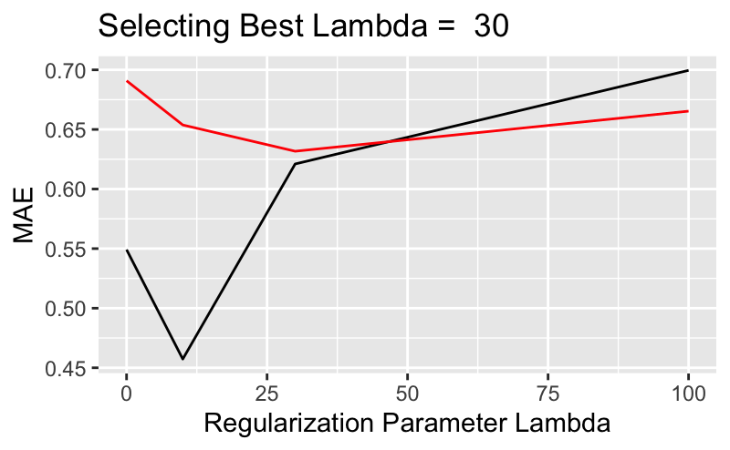

```r
lambda_vec = c(0,10,30,100)
maxit = 100
selectLambda(Y, R, Yval, Rval, num_features, lambda_vec, maxit)
```

### Analysis

```r
# Parameters
lambda = 30
maxit = 1000
num_items = nrow(Y)
num_users = ncol(Y)
X = matrix(rnorm(num_items*num_features), nrow = num_items, ncol = num_features)
Theta = matrix(rnorm(num_users*num_features), nrow = num_users, ncol = num_features)
initial_parameters = c(t(X), t(Theta))
# Preprocess data
L = normalizeRatings(Y, R)
Ymean = L[[1]]
Ynorm = L[[2]]
# Train
costFn = function(t) cofiCostFunc(t, Ynorm, R, num_users, num_items, num_features, lambda)[[1]]
gradFn = function(t) cofiCostFunc(t, Ynorm, R, num_users, num_items, num_features, lambda)[[2]]
modelCoFi = optim(par = initial_parameters, fn = costFn, gr = gradFn, method = c("CG"), control = list(maxit))
params = modelCoFi$par
X = matrix(params[1:(num_items*num_features)], nrow = num_items, ncol = num_features, byrow = T)
Theta = matrix(params[(num_items*num_features+1):length(params)], nrow = num_users, ncol = num_features, byrow = T)
# Predictions
p = X %*% t(Theta)
error = sum(R * abs(p-Ynorm)) / sum(R)
paste("MAE for Collaborative Filtering with Lambda=30 on Training Set:", error)
```

```
[1] "MAE for Collaborative Filtering with Lambda=30 on Training Set: 0.621000006282214"
```

### Test and recommend

We will be testing collaborative filtering on my personal ratings and make movie recommendations for myself.

```r
movieList[movieList$label==4069,]
```

|  | movieId | title | genres | label |
| --- | --- | --- | --- | --- |
| 5323 | 5418 | Bourne Identity, The (2002) | Action\|Mystery\|Thriller | 4069 |

```r
#  Initialize my ratings
my_ratings = rep(0, nrow(movieList))
# Check `movieList` for label of each movie. For example, Leaving Las Vegas (1995) has labeled by 25, so to rate it "4".
my_ratings[25] = 4 # Leaving Las Vegas (1995)
my_ratings[99] = 4 # Braveheart (1995)
my_ratings[100] = 3 # Taxi Driver (1976)
my_ratings[109] = 3 # Chungking Express (Chung Hing sam lam) (1994)
my_ratings[123] = 3.5 # Apollo 13 (1995)
my_ratings[138] = 3.5 # Die Hard: With a Vengeance (1995)
my_ratings[179] = 3.5 # Waterworld (1995)
my_ratings[280] = 4.5 # Shawshank Redemption, The (1994)
my_ratings[316] = 4.5 # Forrest Gump (1994)
my_ratings[324] = 4 # Lion King, The (1994)
my_ratings[349] = 2.5 # Street Fighter (1994)
my_ratings[391] = 4 # Farewell My Concubine (Ba wang bie ji) (1993)
my_ratings[422] = 4 # Jurassic Park (1993)
my_ratings[1002] = 3.5 # Groundhog Day (1993)
my_ratings[1007] = 3.5 # Back to the Future (1985)
my_ratings[1034] = 2.5 # Pink Floyd: The Wall (1982)
my_ratings[1102] = 4 # Jaws (1975)
my_ratings[1334] = 4.5 # Good Will Hunting (1997)
my_ratings[4069] = 4.5 # Bourne Identity, The (2002)
my_ratings[4614] = 4.5 # Laputa: Castle in the Sky (1986)
my_ratings[7939] = 4 # Hangover, The (2009)
for (i in 1:length(my_ratings)) {
  if (my_ratings[i] > 0) {
    x = paste("Rated", my_ratings[i], "for", movieList$title[movieList$label==i])
    cat(x,"\n")
  }
}
```

```
Rated 4 for Leaving Las Vegas (1995)
Rated 4 for Braveheart (1995)
Rated 3 for Taxi Driver (1976)
Rated 3 for Chungking Express (Chung Hing sam lam) (1994)
Rated 3.5 for Apollo 13 (1995)
Rated 3.5 for Die Hard: With a Vengeance (1995)
Rated 3.5 for Waterworld (1995)
Rated 4.5 for Shawshank Redemption, The (1994)
Rated 4.5 for Forrest Gump (1994)
Rated 4 for Lion King, The (1994)
Rated 2.5 for Street Fighter (1994)
Rated 4 for Farewell My Concubine (Ba wang bie ji) (1993)
Rated 4 for Jurassic Park (1993)
Rated 3.5 for Groundhog Day (1993)
Rated 3.5 for Back to the Future (1985)
Rated 2.5 for Pink Floyd: The Wall (1982)
Rated 4 for Jaws (1975)
Rated 4.5 for Good Will Hunting (1997)
Rated 4.5 for Bourne Identity, The (2002)
Rated 4.5 for Laputa: Castle in the Sky (Tenkû no shiro Rapyuta) (1986)
Rated 4 for Hangover, The (2009)
```

```r
Y1 = cbind(my_ratings, Y)
my_R = ifelse(my_ratings!=0, 1, 0)
R1 = cbind(my_R, R)
```

```r
# Parameters
lambda = 30
maxit = 1000
#num_items = nrow(Y1)
num_users = ncol(Y1)
#X = matrix(rnorm(num_items*num_features), nrow = num_items, ncol = num_features)
Theta1 = matrix(rnorm(num_users*num_features), nrow = num_users, ncol = num_features)
initial_parameters1 = c(t(X), t(Theta1))
# Preprocess data
L1 = normalizeRatings(Y1, R1)
Y1mean = L1[[1]]
Y1norm = L1[[2]]
# Train
costFn = function(t) cofiCostFunc(t, Y1norm, R1, num_users, num_items, num_features, lambda)[[1]]
gradFn = function(t) cofiCostFunc(t, Y1norm, R1, num_users, num_items, num_features, lambda)[[2]]
modelCoFi1 = optim(par = initial_parameters1, fn = costFn, gr = gradFn, method = c("CG"), control = list(maxit))
params1 = modelCoFi1$par
#X = matrix(params[1:(num_items*num_features)], nrow = num_items, ncol = num_features, byrow = T)
Theta1 = matrix(params1[(num_items*num_features+1):length(params1)], nrow = num_users, ncol = num_features, byrow = T)
# Predictions
p1 = X %*% t(Theta1)
error_test = sum(R1[,1] * abs(p1[,1]-Y1norm[,1])) / sum(R1[,1])
paste("MAE for Collaborative Filtering with Lambda=30 on Test Set:", error_test)
```

```
[1] "MAE for Collaborative Filtering with Lambda=30 on Test Set: 0.437620811449946"
```

```r
my_pred = p1[,1] + Y1mean
names(my_pred) = movieList$label
idx = as.numeric(names(sort(my_pred, decreasing = T)))
cat("Top recommendations for you:\n")
```

```
Top recommendations for you:
```

```r
for (i in 1:10) {
  j = idx[i] # the label in `movieList`
  x = paste("Predicting rating", my_pred[movieList$label==j], "for movie", movieList$title[movieList$label==j])
  print(x)
}
```

```
[1] "Predicting rating 5.00000497040769 for movie Eighth Day, The (Huitième jour, Le) (1996)"
[1] "Predicting rating 5.00000384230486 for movie Whole Wide World, The (1996)"
[1] "Predicting rating 5.00000338847651 for movie Cannery Row (1982)"
[1] "Predicting rating 5.00000321470368 for movie Dave Chappelle: For What it's Worth (2004)"
[1] "Predicting rating 5.00000272738203 for movie Lava (2015)"
[1] "Predicting rating 5.00000272178879 for movie Troubled Water (DeUsynlige) (2008)"
[1] "Predicting rating 5.00000269259874 for movie Dylan Moran: Like, Totally (2006)"
[1] "Predicting rating 5.00000261393984 for movie Black Death (2010)"
[1] "Predicting rating 5.00000259292668 for movie Bill Burr: You People Are All the Same (2012)"
[1] "Predicting rating 5.00000256938103 for movie Enemies of Reason, The (2007)"
```

```r
cat("\nOriginal ratings provided:\n")
```

```
Original ratings provided:
```

```r
for (i in 1:length(my_ratings)) {
  if (my_ratings[i] > 0) {
    x = paste("Rated", my_ratings[i], "for", movieList$title[movieList$label==i])
    print(x)
  }
}
```

```
[1] "Rated 4 for Leaving Las Vegas (1995)"
[1] "Rated 4 for Braveheart (1995)"
[1] "Rated 3 for Taxi Driver (1976)"
[1] "Rated 3 for Chungking Express (Chung Hing sam lam) (1994)"
[1] "Rated 3.5 for Apollo 13 (1995)"
[1] "Rated 3.5 for Die Hard: With a Vengeance (1995)"
[1] "Rated 3.5 for Waterworld (1995)"
[1] "Rated 4.5 for Shawshank Redemption, The (1994)"
[1] "Rated 4.5 for Forrest Gump (1994)"
[1] "Rated 4 for Lion King, The (1994)"
[1] "Rated 2.5 for Street Fighter (1994)"
[1] "Rated 4 for Farewell My Concubine (Ba wang bie ji) (1993)"
[1] "Rated 4 for Jurassic Park (1993)"
[1] "Rated 3.5 for Groundhog Day (1993)"
[1] "Rated 3.5 for Back to the Future (1985)"
[1] "Rated 2.5 for Pink Floyd: The Wall (1982)"
[1] "Rated 4 for Jaws (1975)"
[1] "Rated 4.5 for Good Will Hunting (1997)"
[1] "Rated 4.5 for Bourne Identity, The (2002)"
[1] "Rated 4.5 for Laputa: Castle in the Sky (Tenkû no shiro Rapyuta) (1986)"
[1] "Rated 4 for Hangover, The (2009)"
```